# The Detection of Redlining in Chicago Insurance Data

STAT7026 Final Project Part B

## Background

*Redlining* is a practice of denying services, either directly or through selectively raising prices, to residents of certain areas based on the racial or ethnic composition of those areas.[^1] In this report, we are investigating data collected by the U.S. Commission on Civil Rights to examine charges that insurance companies were “redlining” certain neighbourhoods in Chicago in the 1970s.

## Data Cleaning and Manipulation

The data is stored by Zip codes and each zip code has a series of corresponding variables `Fire`,`Theft`,`Income`,`Race` and `Age`. The dependent variables we are interested are `Volun` and `Invol`. Using `Invol` only to represent insurability of insurance companies might not be appropriate, since the willingness of people to buy insurance differs. In other words, low value of `Invol` in a district (zip code area) does not guarantee it is redlining-free. It could be due to education background that people simple don’t want to buy insurance. Therefore, we construct a new variable called `rRej` (rate of rejection) by calculating the ratio between `Invol` and `Volun+Invol`. In this way, `rRej` is the proportion of people who were rejected by private insurance companies (hence had to buy FAIR from government), to **roughly** all people who wanted to buy insurance.

$$\text{rRej}=\frac{\text{Invol}}{\text{Invol+Volun}}$$

The only drawback of rewriting is that some people could give up on buying insurance from government after being rejected by insurance companies. The main obstruction here is low income. People could stop buying or renewing insurance simply because they were not able to afford it. So there could be loss from `Volun` to `Invol`, hence our `rRej` could be overestimated. But generally we believe this is a better expression than `Invol` itself.

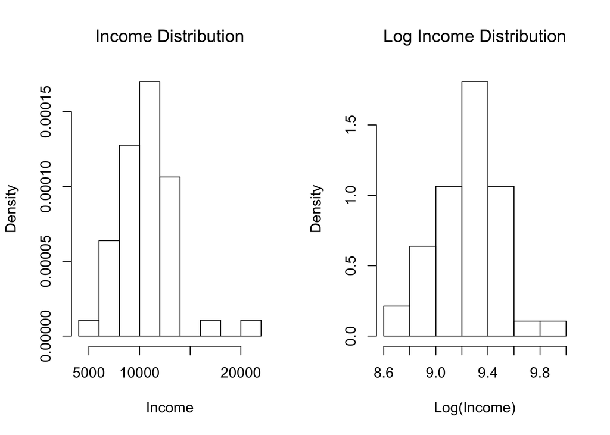

Moreover, we extracted the longitude and latitude based on Jeffrey Breen’s R package `zipcode`. [^2] One funny thing to notice is that Jeffrey’s zipcode data was updated in 2011, but the zipcodes of Chicago we are dealing with can be traced back to 40 years ago. And in fact, by comparison, we found two of those zip codes $60627$ (near Dolton) and $60635$ (near Elmwood Park) were abandoned. This cannot stop us, however, we manually input the related geo-location information.

And last but not least, based on a map of community areas in Chicago [^3], we divided 1970s zip code map into 9 major communities and stored this information in a new variable `Suburb`. On a larger scale, we cluster the communities into 3 regions: *North side*, *West side* and *South side*. The classification of regions is stored in a new varialbe `NSW`. Additionally, we added an alternative classification which combines North side and West side together as the new *North side* and *South side* as before. (See Figure 1 in Appendix for more details.)

## Exploratory Analysis

First we use scatter matrix to get a general idea about how variables are correlated.

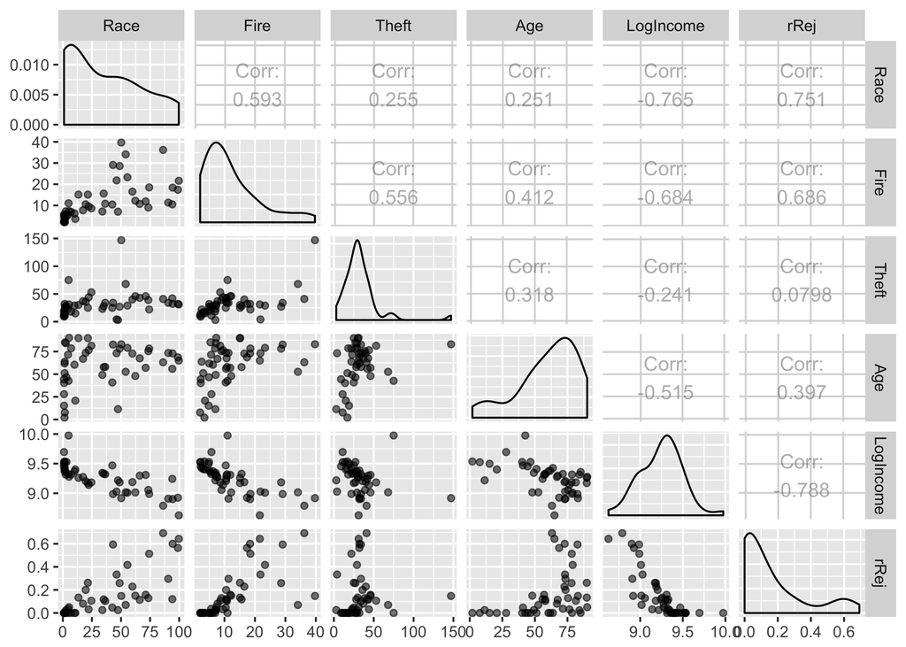

We observed that the response `rRej` is postively correlated with `Race` and `Fire`, which is not surprising. We are suspicious that insurance companies are performing redlining, and traditionally fire risk is a concern for insurance companies when evaluating an insurance case. `LogIncome` is negatively correlated with `rRej`. Although may sound cruel, refusing selling or renewing insurance to poor people is legal. Another secret here is that `LogIncome` is highly correlated with `Race`. This entwinement can really cause some problems as high rejection rate can be explained by low income which is legal, or it can be explaiend by high percentage of racial minorities.

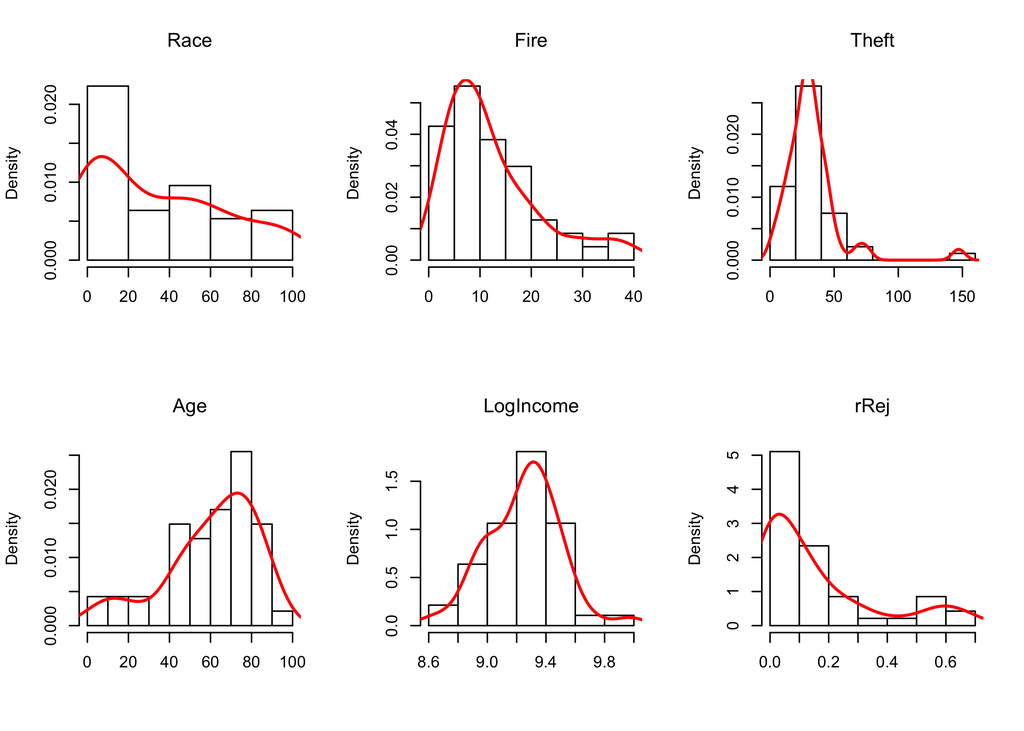

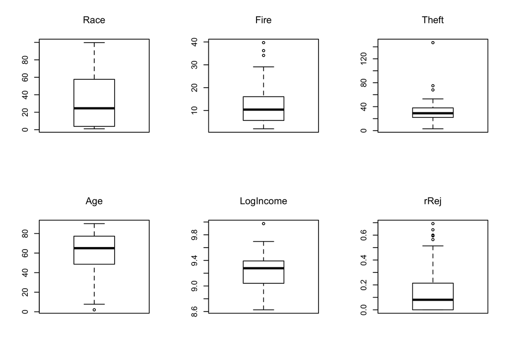

Then we plot the histograms and boxplots of response and predictors. Note that the mid 50-percentile of `Race` has a rather large range approximately from $0$ to $60$. To conclude, the level of racial diversity of Chicago is very high. Districts vary from districts. Since we are studying the effects of `Race`, we really need to take locations into consideration.

## Model Building

Our goal in this part is to fit an appropriate linear model for rejection rate. And the target predictor is `Race`. We can simply fit in a reduced model with one predictor `Race` only. The result is quite satisfying, `Race` shows its significance when other variables are ignored. (Detailed summary table is skipped since it provides not much information about other variables but `Race`.)

```
Call:
lm(formula = rRej ~ Race, data = insure)

Residuals:
     Min       1Q   Median       3Q      Max
-0.30790 -0.06105 -0.00016  0.03663  0.40157

Coefficients:
              Estimate Std. Error t value Pr(>|t|)
(Intercept) -0.0070219  0.0288171  -0.244    0.809
Race         0.0046220  0.0006057   7.630  1.2e-09 ***
---
Signif. codes:  0 '***' 0.001 '**' 0.01 '*' 0.05 '.' 0.1 ' ' 1

Residual standard error: 0.1339 on 45 degrees of freedom
Multiple R-squared:  0.5641,    Adjusted R-squared:  0.5544
F-statistic: 58.22 on 1 and 45 DF,  p-value: 1.196e-09
```

The next step is trying to fit a full model with all predictors in an order of `Fire`, `Theft`, `LogIncome`, `Race` and `Age`. We particularly pick this order because we tend to treat `Race` and `Age` as extra reasons explaining variabilities when fitting the model. That is to say, we believe those insurance companies made their decisions first based on those legit reasons, then based on the factors that redlining is built on.

```
Call:
lm(formula = rRej ~ Fire + Theft + LogIncome + Race + Age, data = insure)

Residuals:
      Min        1Q    Median        3Q       Max
-0.266383 -0.052177 -0.007906  0.043626  0.203596

Coefficients:
              Estimate Std. Error t value Pr(>|t|)
(Intercept)  1.4162387  1.1262226   1.258 0.215684
Fire         0.0104839  0.0025595   4.096 0.000193 ***
Theft       -0.0033497  0.0008227  -4.071 0.000208 ***
LogIncome   -0.1545067  0.1168250  -1.323 0.193316
Race         0.0023457  0.0007269   3.227 0.002461 **
Age          0.0010742  0.0008012   1.341 0.187358
---
Signif. codes:  0 '***' 0.001 '**' 0.01 '*' 0.05 '.' 0.1 ' ' 1

Residual standard error: 0.09767 on 41 degrees of freedom
Multiple R-squared:  0.7886,    Adjusted R-squared:  0.7628
F-statistic: 30.59 on 5 and 41 DF,  p-value: 7.963e-13
```

|  | Df | Sum Sq | Mean Sq | F value | Pr(>F) |
| --- | --- | --- | --- | --- | --- |
| Fire | 1 | 0.86980616 | 0.869806165 | 91.175350 | 5.592255e-12 |
| Theft | 1 | 0.24362533 | 0.243625329 | 25.537442 | 9.442361e-06 |
| LogIncome | 1 | 0.24458865 | 0.244588651 | 25.638420 | 9.143377e-06 |
| Race | 1 | 0.08379784 | 0.083797836 | 8.783908 | 5.042824e-03 |
| Age | 1 | 0.01715106 | 0.017151065 | 1.797819 | 1.873582e-01 |
| Residuals | 41 | 0.39113700 | 0.009539927 | NA | NA |

## References

- In regression analysis what does taking the log of a variable do, https://stats.stackexchange.com/questions/40907/in-regression-analysis-what-does-taking-the-log-of-a-variable-do
- Mapping Inequality: Redlining in New Deal America, https://dsl.richmond.edu/panorama/redlining/#loc=4/36.71/-96.93&opacity=0.8
- Redlining, Encyclopedia of Chicago, http://www.encyclopedia.chicagohistory.org/pages/1050.html
- Faraway book chapter 12
- Principal Component Analysis in R, https://poissonisfish.wordpress.com/2017/01/23/principal-component-analysis-in-r/

## Appendix

[figure not shown]

## TODO list

- what else can we learn from histo and boxplots
- ggplot2 all plots
- unify tenses
- add references
- proof-reading
[^1]: Redlining, Wikipedia, https://en.wikipedia.org/wiki/Redlining
[^2]: My first R package: zipcode, by Jeffrey Breen, https://jeffreybreen.wordpress.com/2011/01/05/cran-zipcode/
[^3]: Community areas in Chicago, Wikipedia, https://en.wikipedia.org/wiki/Community_areas_in_Chicago